# Project 1

James Eapen

2021 Oct 11

[source](https://github.com/jamespeapen/expdesign/blob/gh-pages/p1final.rmd)

## Introduction

Assignments for Experimental Design and Biostatistics class are supposed to take around six hours a week. Assignments are either readings or labs and come from three soures: Software Carpentry for R, Experimental Design for Biologists, and An Introduction to Statistical Learning. Since the class is new, the time that assignments in the class takes has not previously been been studied. A study found that web based homewok resulted in better test scores compared to pen-and-paper homework (Jonsdottir, Bjornsdottir, and Stefansson (2017)). In this class we use R instead of pen-and-paper calculations and it may be a good approach. Understanding the factors that influence the time taken to do homework will allow future assignments to be planned more effectively to take no more than the allotted time for the class and make sure that any improvements in learning from a web based and electronic statistical learning framework are taken advantage of.

Based on the experience doing the homework, I hypothesize that the assignment source and assignment type will be the best predictors of duration.

## Methods

### Design

During the course, students have been recording their start and end times for each assignment through a survey. The independent variables collected were:

- a random student ID
- assignment name
- comments about the assignment

The dependent variable was the duration, calculated as the difference between the start and end times. After collecting the dataset, I further grouped the data by the the type of assignment (reading or lab) and the source of the assignment. Since some students made comments while others did not, I also made a binary variable coding whether or not there was a comment for each entry.

## Results

### Number of assignments done per person

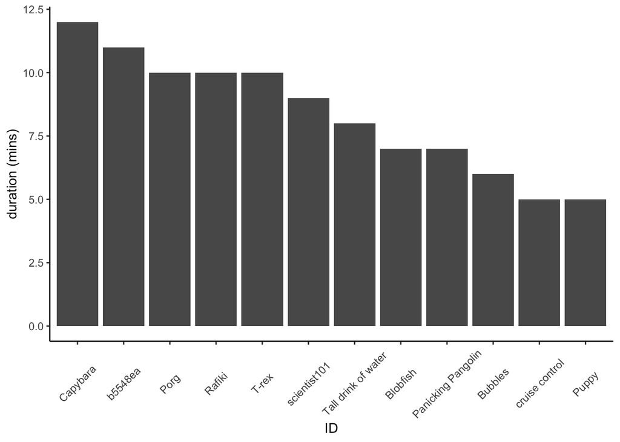

Number of assignments recorded for each student

The data show that there are differences between the number of assignments reported in the survey by each student.

### Time taken per person

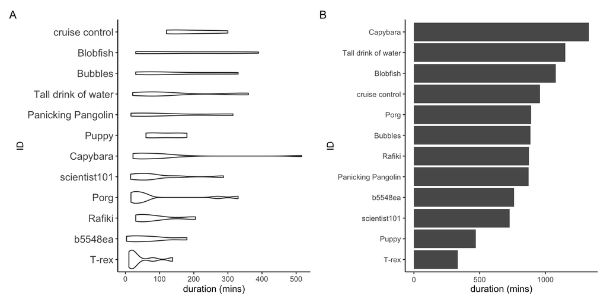

Time taken to complete assignments for each student. **A** shows that for there is considerable variation in the spread of duration for each person. The total time taken for all assignments for each student shown by **B** also reveals large variations between the students.

### Time taken per assignment

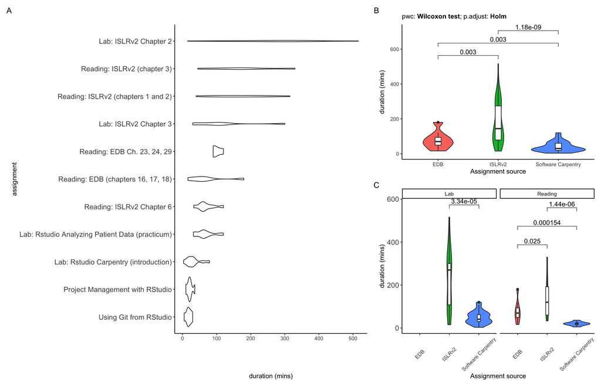

This panel shows the time taken for each assignment based on assignment name, source and type. **A** shows that like the IDs, there is quite a lot of variation in time taken for each specific assignment and some assignments have larger duration ranges than others. **B** shows the duration by the source of the assignment while **C** shows the duration by both source and type of assignment. ISLRv2 assignments have a wider range and take longer than the assignments from EDB and Software Carpentry. p-values are from pairwise Wilcoxon tests, but the tests have not accounted for random effects.

### Time by comment

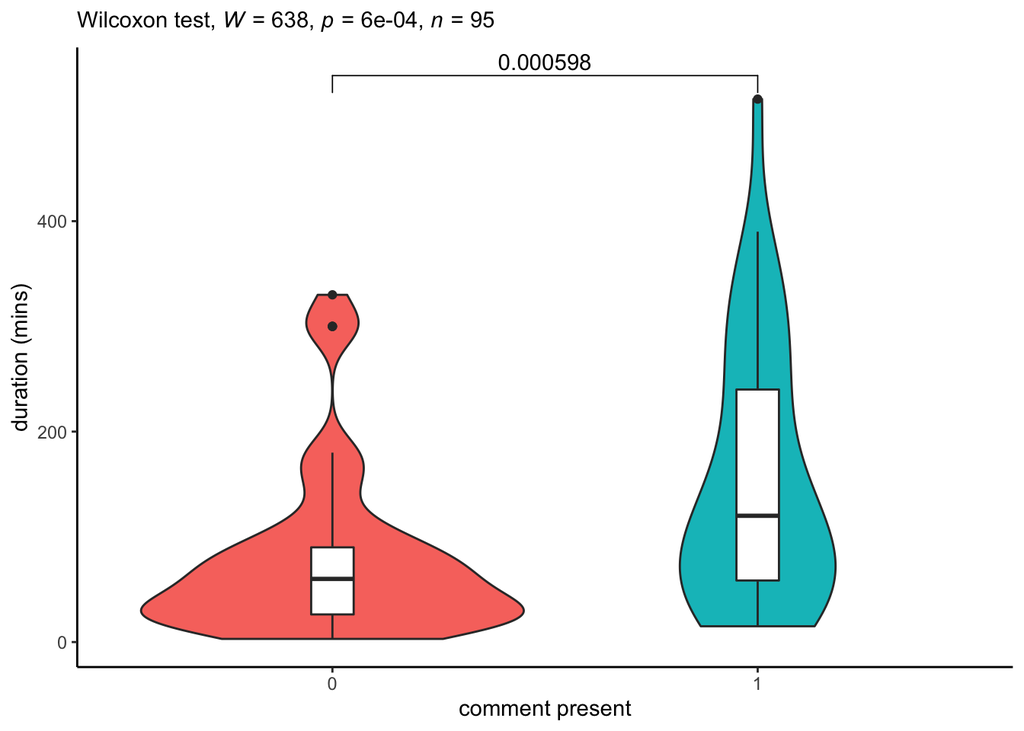

Among the students who made comments, there were a greater number who took longer than 200 minutes to complete the assignment than among the students who did not record any comments. The p-value is from a Wilcoxon test without accounting for random effects.

## Analysis

### Examine dependent variable

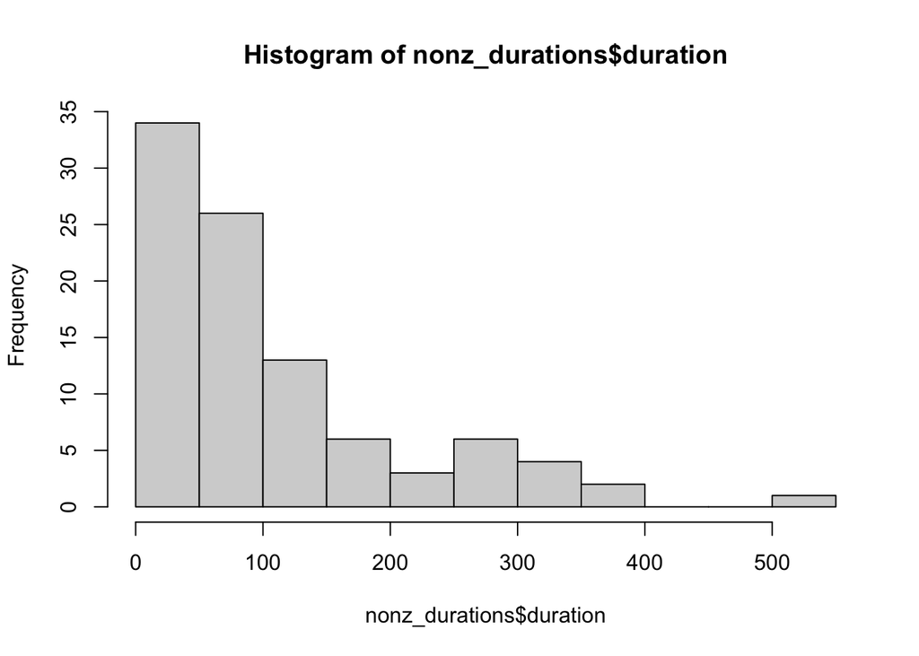

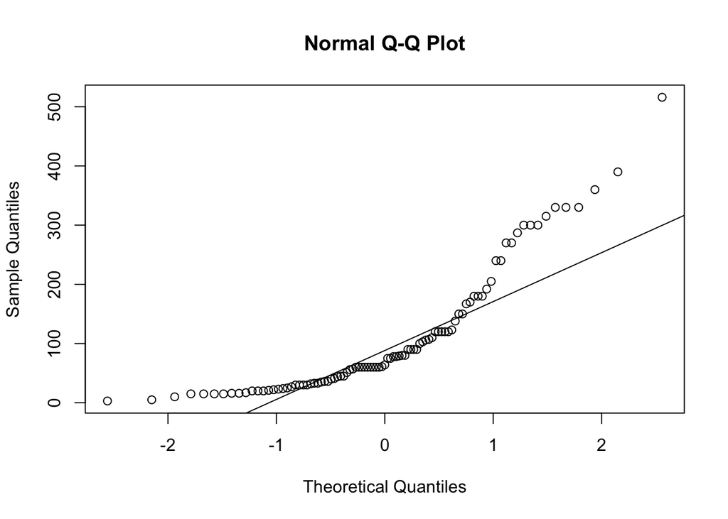

The durations are not normally distributed, but have a strong right skew so I log-normalized the data.

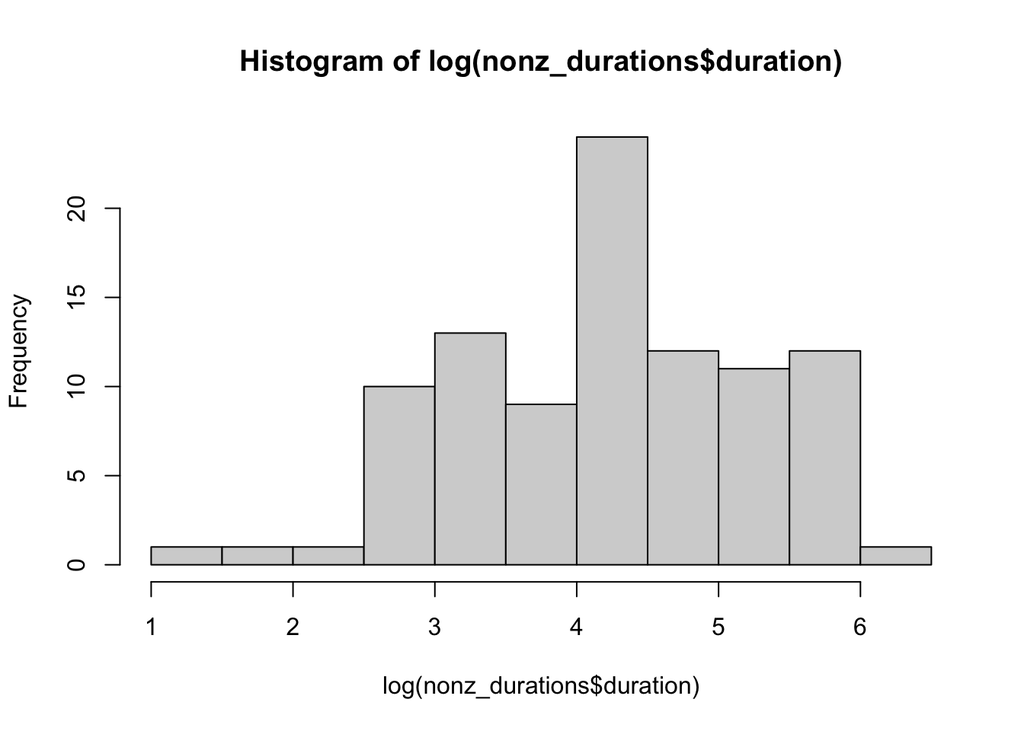

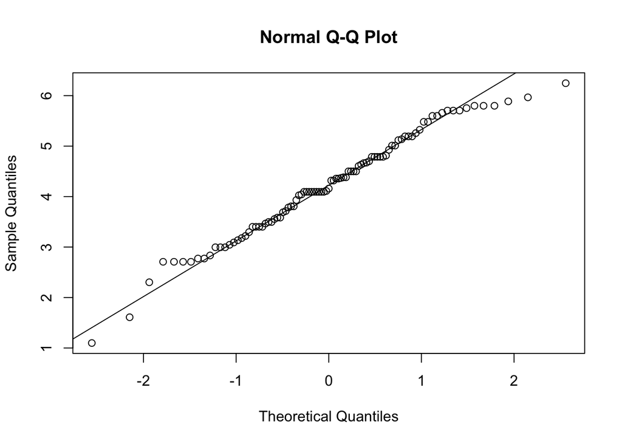

Log-normalization has reduced the skew.

### Mixed effects model

Since there is a lot of variation in the durations betweenn students and between assignments, I fit a mixed effects model using the student ID and assignment as random effects and comment presence, assignment source and assignment type as predictors. The assignment source and types were modelled as interaction terms since the type of assignment depended on where it came from.

Then I ran `dredge` on the model to get the known effect predictor that had the greatest effect on the duration.

|  | (Intercept) | assignment_source | assignment_type | comment_present | assignment_source:assignment_type | df | logLik | BIC | delta | weight |
| --- | --- | --- | --- | --- | --- | --- | --- | --- | --- | --- |
| 2 | 4.305464 | + |  |  |  | 6 | -101.01513 | 229.3535 | 0.000000 | 0.642952738 |
| 1 | 4.231565 |  |  |  |  | 4 | -107.27918 | 232.7739 | 3.420331 | 0.116268920 |
| 4 | 4.669412 | + | + |  |  | 7 | -100.58445 | 233.0460 | 3.692516 | 0.101475063 |
| 6 | 4.200830 | + |  | + |  | 7 | -100.89335 | 233.6638 | 4.310312 | 0.074508639 |
| 12 | 4.913500 | + | + |  | + | 8 | -99.87189 | 236.1748 | 6.821270 | 0.021230439 |
| 3 | 4.310927 |  | + |  |  | 5 | -106.96428 | 236.6979 | 7.344417 | 0.016344027 |
| 5 | 4.141125 |  |  | + |  | 5 | -107.19931 | 237.1680 | 7.814471 | 0.012920766 |
| 8 | 4.533055 | + | + | + |  | 8 | -100.59010 | 237.6112 | 8.257693 | 0.010352467 |
| 16 | 4.795957 | + | + | + | + | 9 | -99.85516 | 240.6952 | 11.341684 | 0.002214949 |
| 7 | 4.204872 |  | + | + |  | 6 | -106.93193 | 241.1871 | 11.833598 | 0.001731992 |

The model with only `assignment_source` as a predictor seems to be the best one.

I then ran two mixed models with assignment source as the known effect. Between a mixed model with only ID as a random effect (`re_id`) and a mixed model with both ID and assignment as random effects (`re_id_assignment`), the latter has a lower BIC.

|  | npar | AIC | BIC | logLik | deviance | Chisq | Df | Pr(>Chisq) |
| --- | --- | --- | --- | --- | --- | --- | --- | --- |
| re_id | 5 | 224.0612 | 236.8306 | -107.03058 | 214.0612 |  |  |  |
| re_id_assignment | 6 | 211.4940 | 226.8173 | -99.74702 | 199.4940 | 14.56712 | 1 | 0.0001353 |

### Model diagnostics

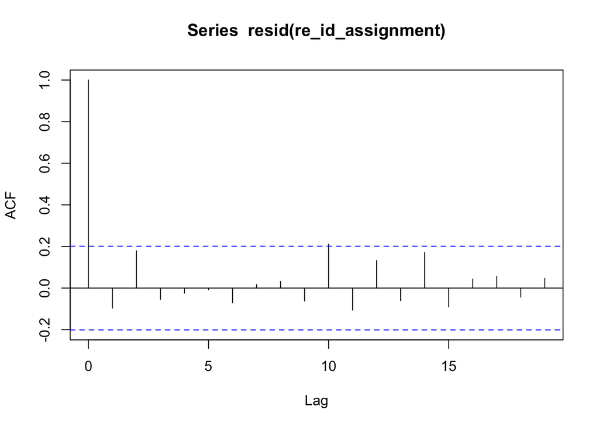

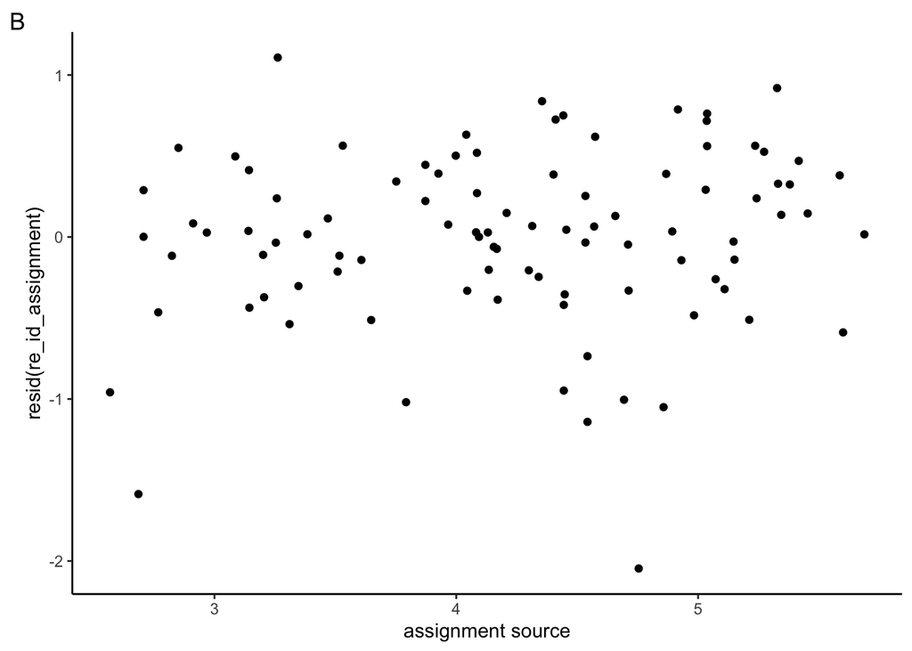

Residual independence and variance

Model diagnostics show that the residuls are independent and have a constant variance.

### Coefficient estimates

| assignment_source | response | SE | df | lower.CL | upper.CL |
| --- | --- | --- | --- | --- | --- |
| EDB | 74.10362 | 26.887216 | 9.802267 | 32.94392 | 166.68770 |
| ISLRv2 | 133.11606 | 31.481169 | 10.883960 | 79.04548 | 224.17329 |
| Software Carpentry | 29.65755 | 7.724925 | 10.414146 | 16.65091 | 52.82415 |

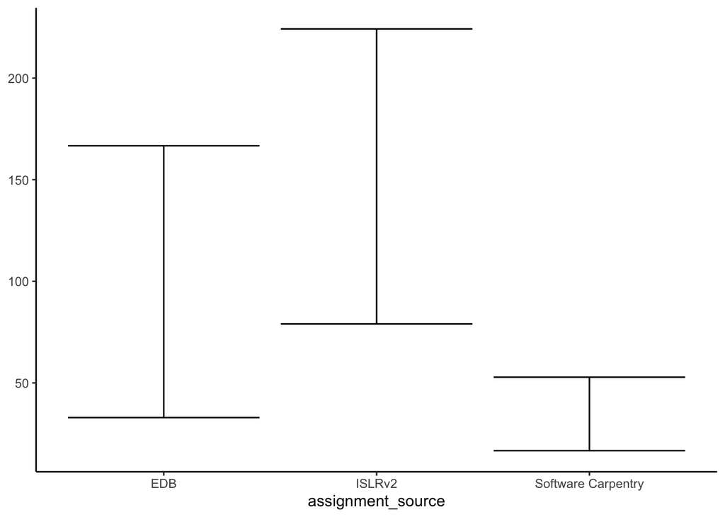

The table above shows the back-transformed coefficient estimates and their confidence intervals. The figure shows that the confidence intervals are large, especially for the ISLRv2 and EDB sources.

| contrast | ratio | SE | df | null | t.ratio | p.value |
| --- | --- | --- | --- | --- | --- | --- |
| EDB / ISLRv2 | 0.5566843 | 0.2275092 | 8.245875 | 1 | -1.433269 | 0.3689738 |
| EDB / Software Carpentry | 2.4986429 | 1.0606483 | 8.313584 | 1 | 2.157291 | 0.1371153 |
| ISLRv2 / Software Carpentry | 4.4884380 | 1.4450241 | 7.862126 | 1 | 4.663875 | 0.0042509 |

An `emmeans` test reveals that the differences in durations between the ISLRv2 and the Software Carpentry sources are significant (p $\le$ 0.05).

## Conclusions

The mixed model show that the source of the assignment plays an important role in determining how long students take to complete the assignment, partially confirming my hypothesis. I suspect that there were no significant differences between the ISLRv2 and EDB sources because ISLRv2 based assignments were given one chapter at a time while we had 3 EDB assignments for a week. Breaking it down by chapter may better elucidate the differences between sources.

By taking the student IDs and the assignments as random effects, I hoped to account for variations in student experience with statistics and R as well as differences in the way that students went about doint the assignments. However the large confidence intervals for the coefficients make me question the relevance and applicability of this model.

Data exploration also showed that, to a degree, students who take a long time seem more likely to be students who make comments on the assignment.

One of the weaknesses of this model is the lack of complete data. Not all the assignments done were recoreded and this has likely reduced the power of the model and its applicability. Accounting for differences in the way they were entered, there should be between 10 and 12 assignments for each student, but some students had only 5 records. Future studies should have a way of confirming that every student records data from each assignment.

## References

Jonsdottir, Anna Helga, Audbjorg Bjornsdottir, and Gunnar Stefansson. 2017. “Difference in Learning Among Students Doing Pen-and-Paper Homework Compared to Web-Based Homework in an Introductory Statistics Course.” *Journal of Statistics Education* 25 (1): 12–20. https://doi.org/10.1080/10691898.2017.1291289.